# CA04_Spring403

### Q29: Overfitting/ Underfitting

### KNN

```python
from sklearn.neighbors import KNeighborsClassifier


class KNNModel(ClassifierModel):
    def create_classifier(self, params):
        return KNeighborsClassifier(n_neighbors = params["n_neighbors"])

    def set_search_params(self):
        return {
                'n_neighbors' : range(1, 90)
        }

    def check_overfit_underfit(self, param_range, train_scores, test_scores):
        plt.figure(figsize=(10, 6))
        plt.plot(param_range, train_scores, label="Train Accuracy", marker='o')
        plt.plot(param_range, test_scores, label="Test Accuracy", marker='o')
        plt.xlabel('Model Complexity')
        plt.ylabel('Accuracy')
        plt.title('Overfitting vs Underfitting')
        plt.legend()
        plt.grid(True)
        plt.show()
```

```
model's train accuracy:  0.782
model's test accuracy:  0.794
Best hyperparameters: {'n_neighbors': 3}
Best model's train accuracy score: 0.802
Best model's test score: 0.804
```

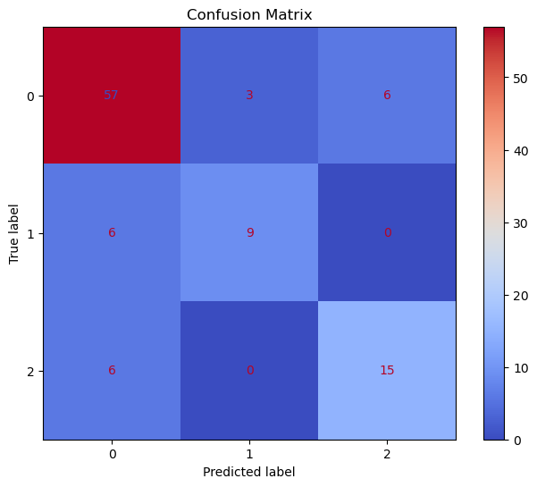

```python
params = {
        'n_neighbors' : 18
}
run_model(KNNModel, X_train, y_train, X_test, y_test, params)
```

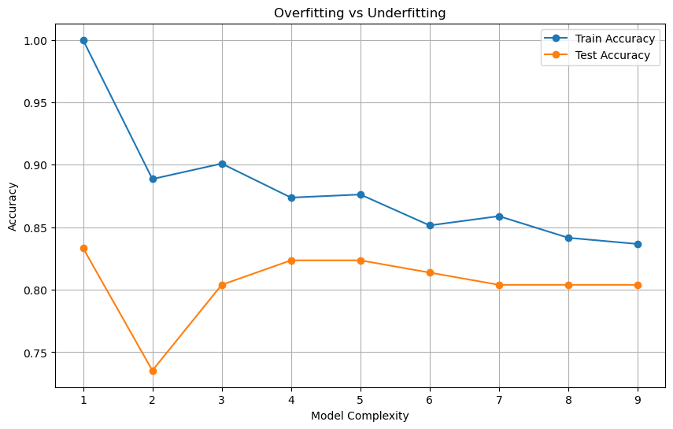

```python
param_range = range(1, 10)

train_scores = []
test_scores = []

for n_neighbors in param_range:
    knn_model = KNNModel(X_train, y_train, {'n_neighbors': n_neighbors})
    knn_model.classifier.fit(X_train, y_train)
    train_accuracy = knn_model.calc_accuracy(X_train, y_train)
    test_accuracy = knn_model.calc_accuracy(X_test, y_test)

    train_scores.append(train_accuracy)
    test_scores.append(test_accuracy)

knn_model.check_overfit_underfit(param_range, train_scores, test_scores)
y_pred_knn = knn_model.predict(X_test)
```

### Q38: what is XGBoost

XGBoost, short for Extreme Gradient Boosting, is an efficient and scalable implementation of gradient boosting framework. It works by sequentially adding weak learners (decision trees) to the ensemble, where each subsequent learner corrects the errors made by the previous ones. XGBoost optimizes a loss function by employing gradient descent algorithm and regularization techniques to prevent overfitting. It utilizes parallel computing and tree pruning algorithms to enhance computational speed and model accuracy. Overall, XGBoost is known for its high performance, versatility, and ability to handle large-scale datasets across various machine learning tasks such as classification, regression, and ranking.

### Q39: Gradient-Boosting

Gradient boosting is a popular machine learning technique for building predictive models. It involves combining multiple weak models, typically decision trees, to create a strong ensemble model. The basic idea is to fit a sequence of simple models to the residuals of the previous model, with the objective of minimizing a loss function. This process continues until a stopping criterion is met, such as a maximum number of iterations or a minimum improvement in the loss function.

*Boosting Tree vs Decision Tree:*

*Ensemble vs. Single Model:* Boosting tree is an ensemble learning algorithm that combines multiple weak learners (usually decision trees) into a strong learner, while decision tree is a single model that makes predictions based on a single tree-like structure.

*Iterative vs. Non-Iterative:* Boosting tree is an iterative algorithm that adds new trees to the ensemble iteratively, with each new tree attempting to correct the errors of the previous trees, while decision tree is a non-iterative algorithm that constructs a single tree-like structure based on the input features.

*Bias-Variance Tradeoff:* Boosting tree is designed to reduce both bias and variance, by combining multiple weak learners into a strong learner that can make accurate predictions on new, unseen data, while decision tree is prone to overfitting, especially when the tree is too deep or the number of training samples is too small.

*Hyperparameters:* Boosting tree has several hyperparameters that can be tuned to improve its performance, such as the learning rate, the number of trees in the ensemble, the maximum depth of each tree, and the minimum number of samples required to split a node, while decision tree has fewer hyperparameters, such as the maximum depth of the tree, the minimum number of samples required to split a node, and the splitting criterion.

*Interpretability:* Decision tree is more interpretable than boosting tree, because it produces a single tree-like structure that can be easily visualized and understood, while boosting tree produces an ensemble of trees that can be more difficult to interpret.

```python
from xgboost import XGBClassifier

class XGBModel(ClassifierModel):
    def create_classifier(self, params):
        return XGBClassifier(gamma=1, learning_rate=params["learning_rate"], max_depth=params["max_depth"]
                             , n_estimators=params["n_estimators"])

    def set_search_params(self):
        return {
            'learning_rate': np.arange(0.1, 0.9, 0.05),
            'max_depth': range(5, 10),
            'n_estimators': range(1, 120, 20)
        }
```

```
model's train accuracy:  0.958
model's test accuracy:  0.814
Best hyperparameters: {'learning_rate': 0.25000000000000006, 'max_depth': 8, 'n_estimators': 21}
Best model's train accuracy score: 0.864
Best model's test score: 0.824
```

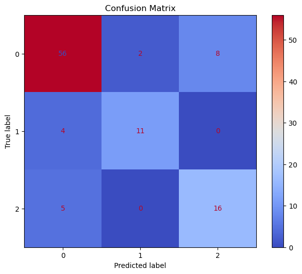

```python
params = {
    "learning_rate" : 0.1,
    "max_depth" : 8,
    "n_estimators": 50
}
run_model(XGBModel, X_train, y_train, X_test, y_test, params)
y_pred_xgb = knn_model.predict(X_test)

# gs_cv_xgb = GridSearchCV(xgb, xgb_params, cv=10, n_jobs=-1, verbose=2).fit(X_train, y_train)
```

```python
from sklearn.linear_model import LogisticRegression

class LogisticRegressionModel(ClassifierModel):
    def create_classifier(self, params):
        return LogisticRegression(max_iter = 500)

    def set_search_params(self):
        return {
            'C': [0.001, 0.01, 0.1, 1, 10, 100, 1000],
            'penalty': ['l2'],
            'solver': ['newton-cg', 'lbfgs', 'liblinear', 'sag', 'saga']
        }
```

```
model's train accuracy:  0.733
model's test accuracy:  0.784
Best hyperparameters: {'C': 1000, 'penalty': 'l2', 'solver': 'sag'}
Best model's train accuracy score: 0.824
Best model's test score: 0.843
```

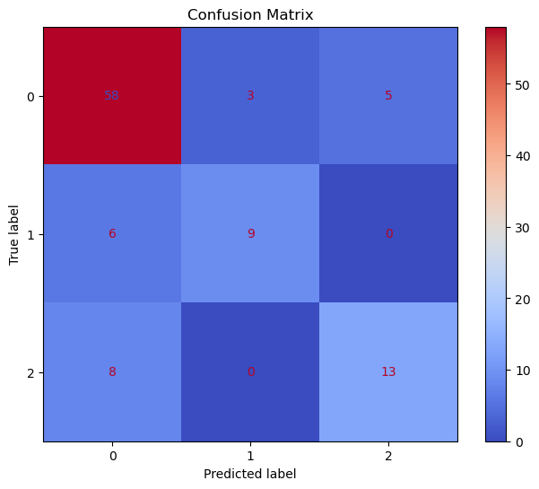

```python
params = {}
run_model(LogisticRegressionModel, X_train, y_train, X_test, y_test, params)
```

## Ensemble Learning

### Q30: Why ensemble methods are useful

Ensemble methods like bagging, boosting, and stacking have become crucial in machine learning due to their ability to improve predictive accuracy, enhance robustness, reduce overfitting, offer flexibility across various tasks, and scale effectively to large datasets. By combining multiple models' predictions, ensemble methods mitigate individual model biases and errors, resulting in more stable and accurate predictions. Their versatility and applicability to diverse types of data, coupled with advancements in computational resources, make ensemble methods indispensable in modern machine learning workflows for tackling complex and challenging predictive modeling tasks.

### Q31: Boosting and Bagging

In bagging (Bootstrap Aggregating), multiple base learners are trained independently on different subsets of the training data, typically created through bootstrapping (sampling with replacement). The final prediction is made by averaging (for regression) or voting (for classification) the predictions of all base learners. Bagging aims to reduce variance and prevent overfitting by combining multiple models' predictions.

In contrast, boosting involves training multiple weak learners sequentially, with each subsequent learner focusing on the samples that the previous ones misclassified. The final prediction is a weighted sum of the predictions of all weak learners. Boosting aims to reduce bias and improve accuracy by iteratively correcting the errors made by earlier models. Unlike bagging, boosting assigns weights to training instances, emphasizing the importance of hard-to-classify examples, which can lead to a stronger overall learner.

### Q33: Bootstrapping in Random Forest

In Random Forest, bootstrapping is a technique used to create multiple subsets of the original dataset by randomly sampling with replacement. Each subset, called a bootstrap sample, has the same size as the original dataset but may contain duplicate instances and may exclude some original instances. These bootstrap samples are then used to train individual decision trees within the Random Forest ensemble.

Bootstrapping helps introduce diversity among the decision trees because each tree is trained on a slightly different subset of the data. This diversity is beneficial because it helps reduce overfitting and improves the overall performance of the Random Forest model. Additionally, bootstrapping allows some instances to be left out of each bootstrap sample, which can be used as "out-of-bag" (OOB) samples for estimating the model's performance without the need for a separate validation set.

### Q34: Number of Decision Tress in Random Forest

The number of decision trees in a Random Forest significantly influences the model's performance. Generally, increasing the number of trees can lead to better performance up to a certain point, after which the improvement may plateau or even decrease due to overfitting.

The optimal number of trees in a Random Forest is typically determined empirically through experimentation and validation. It depends on factors such as the complexity of the dataset, the level of noise, and computational resources. In practice, a common range for the number of trees in a Random Forest is between 10 to 200.

### Q35: When we should use Random Forest

Random Forest is not suitable in scenarios where interpretability is paramount, such as when the model's decision-making process needs to be transparent and easily understandable. Since Random Forest combines multiple decision trees, interpreting the individual trees' decisions becomes more challenging, making it less suitable for applications where interpretability is crucial, such as in legal or medical domains.

On the other hand, Random Forest is highly recommended when dealing with complex datasets with high-dimensional features or when robust performance is required. It excels in handling noisy data, mitigating overfitting, and providing reliable predictions, making it a preferred choice in various real-world applications, including classification and regression tasks in fields like finance, marketing, and bioinformatics. Additionally, its ability to handle large datasets efficiently and its scalability make it well-suited for big data analytics and machine learning tasks in industries with vast amounts of data.

### Q36: Effect of Random Forest on Variance

Random Forest can help reduce the variance of a model. By combining multiple decision trees trained on different subsets of the data, Random Forest averages out the predictions of individual trees, leading to a smoother overall prediction. This averaging process tends to reduce the variance of the model compared to a single decision tree. As a result, Random Forests are less prone to overfitting, which can occur when a model captures noise or idiosyncrasies in the training data rather than learning the underlying patterns. Overall, Random Forests can provide more stable and reliable predictions by reducing variance, making them a popular choice in machine learning tasks where robustness is important.

### Q37: Random Forest Hyperparameters

some of the most important hyperparameters of Random Forest are:

n_estimators: The number of decision trees in the Random Forest. A larger value of n_estimators can improve the performance of the model, but may also increase the training time and memory usage.

criterion: The function used to measure the quality of a split. The default is 'gini', which uses the Gini impurity measure. Another option is 'entropy', which uses the information gain measure.

max_depth: The maximum depth of the decision trees in the Random Forest. A larger value of max_depth can capture more complex patterns in the data, but may also lead to overfitting. A smaller value of max_depth can help prevent overfitting but may also lead to underfitting.

min_samples_split: The minimum number of samples required to split an internal node. A larger value of min_samples_split can help prevent overfitting but may also lead to underfitting.

min_samples_leaf: The minimum number of samples required to be at a leaf node. A larger value of min_samples_leaf can help prevent overfitting but may also lead to underfitting.

max_features: The maximum number of features to consider when making a split. The default is 'auto', which uses the square root of the number of features. Another option is 'sqrt', which uses the square root of the number of features.

class_weight: The weight function used in the classification. The default is None, which means all classes have equal weight. Another option is 'balanced', which automatically adjusts the weights based on the number of samples in each class.

random_state: Controls the randomness of the estimator. If an integer is given, the randomness will be deterministic and the results will be reproducible.

```python
# def hyper_param_compare(param_range, init_params, param):
#     test_accuracy = []
#     train_accuracy = []

#     for i in param_range:
#         init_params[param] = i
#         classifier = RandomForestClassifier(criterion = init_params['criterion'], max_depth = init_params['max_depth'], n_estimators = init_params['n_estimators'])
#         RF = ClassifierModel(classifier, RF)
```

```python
from sklearn.ensemble import RandomForestClassifier

class RandomForestModel(ClassifierModel):
    def create_classifier(self, params):
        return RandomForestClassifier(criterion=params['criterion'], max_depth=params["max_depth"],
                                      n_estimators=params["n_estimators"])

    def set_search_params(self):
        return {
            'n_estimators': range(20, 150, 20),
            'criterion': ['entropy', 'gini'],
            'max_depth': range(5, 10),
        }
```

```
model's train accuracy:  0.988
model's test accuracy:  0.833
Best hyperparameters: {'criterion': 'gini', 'max_depth': 9, 'n_estimators': 140}
Best model's train accuracy score: 0.886
Best model's test score: 0.843
```

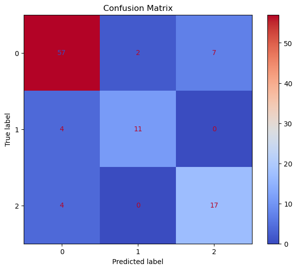

```python
params = {
        'criterion': "gini",
        'max_depth': 9,
        'n_estimators': 40,
}
run_model(RandomForestModel, X_train, y_train, X_test, y_test, params)
```

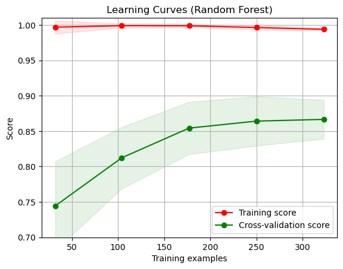

```python
import matplotlib.pyplot as plt
from sklearn.model_selection import learning_curve
from sklearn.model_selection import ShuffleSplit

def plot_learning_curve(estimator, title, X, y, ylim=None, cv=None, n_jobs=None, train_sizes=np.linspace(.1, 1.0, 5)):
    plt.figure()
    plt.title(title)
    if ylim is not None:
        plt.ylim(*ylim)
    plt.xlabel("Training examples")
    plt.ylabel("Score")
    train_sizes, train_scores, test_scores = learning_curve(
        estimator, X, y, cv=cv, n_jobs=n_jobs, train_sizes=train_sizes)
    train_scores_mean = np.mean(train_scores, axis=1)
    train_scores_std = np.std(train_scores, axis=1)
    test_scores_mean = np.mean(test_scores, axis=1)
    test_scores_std = np.std(test_scores, axis=1)
    plt.grid()

    plt.fill_between(train_sizes, train_scores_mean - train_scores_std,
                     train_scores_mean + train_scores_std, alpha=0.1,
                     color="r")
    plt.fill_between(train_sizes, test_scores_mean - test_scores_std,
                     test_scores_mean + test_scores_std, alpha=0.1, color="g")
    plt.plot(train_sizes, train_scores_mean, 'o-', color="r",
             label="Training score")
    plt.plot(train_sizes, test_scores_mean, 'o-', color="g",
             label="Cross-validation score")

    plt.legend(loc="best")
    return plt

title = "Learning Curves (Random Forest)"
cv = ShuffleSplit(n_splits=10, test_size=0.2, random_state=0)
estimator = RandomForestClassifier(criterion=params['criterion'], max_depth=params["max_depth"], n_estimators=params["n_estimators"])
plot_learning_curve(estimator, title, X_train, y_train, ylim=(0.7, 1.01), cv=cv, n_jobs=4)

plt.show()
```

### SVM(Support Vector Machine)

### Q40.3: Random vs Grid search

Considering our dataset's size, Grid Search is preferable for efficiently finding optimal hyperparameters within a short timeframe, while Random Search is more suitable for larger datasets.

```
Best parameters with linear kernel in grid search: {'C': 100}
Best parameters with rbf kernel in grid search: {'C': 1000, 'gamma': 0.001}
Best parameters with linear kernel in random search: {'C': 90.90918181818182}
Best parameters with rbf kernel in random search: {'gamma': 0.09091, 'C': 535.4}
Accuracy with rbf kernel is 0.7941176470588235
Recall with rbf kernel is 0.803921568627451
F1 score with rbf kernel is 0.8024436640327774
```

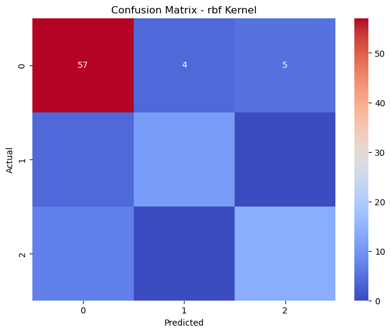

```
Accuracy with linear kernel is 0.8137254901960784
Recall with linear kernel is 0.7941176470588235
F1 score with linear kernel is 0.7900314870473737
```

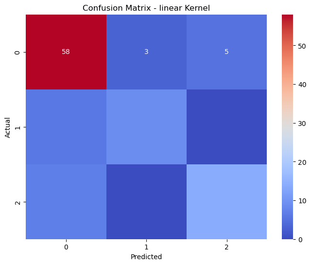

```python
class SVM:
    def __init__(self,kernel, X_train, y_train,X_test, y_test):
        self.kernel = kernel
        self.X_train = X_train
        self.y_train = y_train
        self.X_test = X_test
        self.y_test= y_test
        self.model = SVC(kernel=self.kernel).fit(self.X_train, self.y_train)
        self.y_pred = self.model.predict(self.X_test)

    def grid_search(self, param_grid):
        svc = SVC(kernel=self.kernel)
        grid_search = GridSearchCV(estimator=svc, param_grid=param_grid, scoring='accuracy', cv=5)
        grid_search.fit(self.X_train, self.y_train)
        self.model = grid_search.best_estimator_
        print(f'Best parameters with {self.kernel} kernel in grid search:', grid_search.best_params_)

    def random_search(self, param_dist, n_iter=10, random_state=None):
        svc = SVC(kernel=self.kernel)
        random_search = RandomizedSearchCV(estimator=svc, param_distributions=param_dist, n_iter=n_iter, scoring='accuracy', cv=5, random_state=random_state)
        random_search.fit(self.X_train, self.y_train)
        self.model = random_search.best_estimator_
        print(f'Best parameters with {self.kernel} kernel in random search:', random_search.best_params_)

    def calc_accuracy(self):
        return self.model.score(self.X_test, self.y_test)
    def calc_recall(self):
        return recall_score(self.y_test, self.y_pred, average='weighted')
    def calc_f1(self):
        return f1_score(self.y_test, self.y_pred, average='weighted')
    def plot_confusion_matrix(self):
        cm = confusion_matrix(self.y_test, self.y_pred)
        plt.figure(figsize=(8, 6))
        sns.heatmap(cm, annot=True, fmt="d", cmap="coolwarm",
                    xticklabels=self.model.classes_,
                    yticklabels=self.model.classes_)
        plt.xlabel('Predicted')
        plt.ylabel('Actual')
        plt.title(f'Confusion Matrix - {self.kernel} Kernel')
        plt.show()
    def run(self):
        print(f'Accuracy with {self.kernel} kernel is',self.calc_accuracy())
        print(f'Recall with {self.kernel} kernel is',self.calc_recall())
        print(f'F1 score with {self.kernel} kernel is',self.calc_f1())
        self.plot_confusion_matrix()


# feature_data.split_for_svm('MEDV','label')
rbf_SVM = SVM('rbf', X_train, y_train, X_test, y_test)
linear_SVM = SVM('linear', X_train, y_train, X_test, y_test)
param_grid_linear = {'C': [0.001, 0.01, 0.1, 1, 10, 100]}
param_grid_rbf = {'C': [0.1, 1, 10, 100, 1000], 'gamma': [0.001, 0.0001, 0.00001]}
param_dist_linear = {'C': np.linspace(0.001, 100, 100)}
param_dist_rbf = {'C': np.linspace(0.1, 1000, 100), 'gamma': np.linspace(0.00001, 0.1, 100)}
linear_SVM.grid_search(param_grid_linear)
rbf_SVM.grid_search(param_grid_rbf)
linear_SVM.random_search(param_dist_linear, n_iter=20, random_state=42)
rbf_SVM.random_search(param_dist_rbf, n_iter=20, random_state=42)
rbf_SVM.run()
linear_SVM.run()
```

```python
from sklearn.metrics import classification_report

report_dt = classification_report(y_test, y_pred_dt)
report_knn = classification_report(y_test, y_pred_knn)
report_xgb = classification_report(y_test, y_pred_xgb)

print("Decision Tree Classification Report:")
print(report_dt)
print("\nK-Nearest Neighbors Classification Report:")
print(report_knn)
print("\nXGBoost Classification Report:")
print(report_xgb)

accuracy_dt = accuracy_score(y_test, y_pred_dt)
accuracy_knn = accuracy_score(y_test, y_pred_knn)
accuracy_xgb = accuracy_score(y_test, y_pred_xgb)

print(f"Decision Tree Accuracy: {accuracy_dt:.4f}")
print(f"K-Nearest Neighbors Accuracy: {accuracy_knn:.4f}")
print(f"XGBoost Accuracy: {accuracy_xgb:.4f}")
```

[output not shown]